# 9545 2018 Day 1

# General Info

- This couse will run MW 9:30 - 11:30 AM for 6 sessions beginning Sept 10.
- This course will cover how to use R and markdown to reproducibly analyze data with the emphasis on how to use R for data manipulation and exploration
- There will be an oral evaluation plus notebook examination worth 30%.
- Notebooks must be kept in R markdown and be able to be knit into a html document
- There will be one final takehome assignment worth 70%

## Resources

- All students need to master these [tutorials up to tutorial 4](http://www.ee.surrey.ac.uk/Teaching/Unix/) through self-directed learning.
- There is a good [R markdown cheatsheet](https://github.com/adam-p/markdown-here/wiki/Markdown-Cheatsheet)
- I recommend that students obtain a copy of `R in action` by Robert Kabacoff. In particular, I hope the students in the class become proficient with the concepts and methods in the first 6 chapters. This is one of those books that is worth buying.
- [CRAN also has a decent introduction](https://cran.r-project.org/doc/contrib/Paradis-rdebuts_en.pdf)
- All students will need an up-to-date install of [RStudio](https://www.rstudio.com/), or command line R (if desired) plus a plain text editor

# Basics of R markdown

This is an R markdown document, and the plain text code can be found at [gihub.com/ggloor/9545](https://raw.githubusercontent.com/ggloor/9545/master/Q_section/R_coding_1_anscombe.Rmd) under the 9545/Q section. This is the raw source. You can download it and modify it as you see fit.

If you are in the R console and have this file in the working directory you can compile it manually

`rmarkdown::render("R_coding_1_anscombe.Rmd")`

# Basics of R

R is a programming language by statisticians for statisticians. It is idiosyncratic, but is worth learning despite (not because of) this as it is an extremely useful tool or data analysis. While other statistical analysis programs allow you to do what they have available, R allows you to do what you can imagine.

There are two basic data structures in R, the vector and the list.

```r
# this is a comment, you should use them because your future self is not that bright

# the first base data type is a vector object  and we can make vectors with the c() function
# vectors can contain only one kind of data (number, character, logical)
# the assignment operator is "<-"

x <- c(1,2,3)
y <- c(4,5,6)
z <- c(7,8)

# a two dimensional vector is a matrix
xy <- cbind(x,y)

# the second base data type is a list
# lists can contain anything

xyz <- list(x,y,z,xy)

# a dataframe is a special type of list whereby the vectors must be of the same length

ab <- data.frame(x,y)
```

- what is inside `x`?
- what is inside the other objects?

The unit of computation in R is the function, and you can recognize functions by their round brackets (). Information about functions can be found using the ?function.name notation, and you can get an example by example(“function.name”).

The second type of bracket is the curly bracket{} that is used to keep commands together in functions or logical tests.

## Examining and subsetting datasets

There are a few commands that make understanding your data object tolerable.

- `str(obj)` structure of the object
- `class(obj)` class of the object
- `mode(obj)` the mode of the object
- `names(obj)` the names (or `rownames` or `colnames`) of the object

and many others, but these are the main workhorses. Try them out on the data types made above.

When subsetting datasets there are two ways, and the method used depends if we are subsetting a vector or a list

```r
# subsetting vectors uses square brackets
x[2] # second element of vector x
```

```
## [1] 2
```

```r
xy[3,2] # the third row and second column of matrix xy
```

```
## y
## 6
```

```r
# dataframes can be subset the same way
# lists require double brackets
xyz[[4]][3,2]
```

```
## y
## 6
```

```r
# we can name elements of a list and subset by name
names(xyz) <- c("v_X", "v_Y", "v_Z", "m_xyz")
 xyz$m_xyz[3,2]
```

```
## y
## 6
```

## built in data

R has many built in datasets, of which the anscombe dataset is one of the most famous

```r
data(anscombe)
anscombe
```

```
##    x1 x2 x3 x4    y1   y2    y3    y4
## 1  10 10 10  8  8.04 9.14  7.46  6.58
## 2   8  8  8  8  6.95 8.14  6.77  5.76
## 3  13 13 13  8  7.58 8.74 12.74  7.71
## 4   9  9  9  8  8.81 8.77  7.11  8.84
## 5  11 11 11  8  8.33 9.26  7.81  8.47
## 6  14 14 14  8  9.96 8.10  8.84  7.04
## 7   6  6  6  8  7.24 6.13  6.08  5.25
## 8   4  4  4 19  4.26 3.10  5.39 12.50
## 9  12 12 12  8 10.84 9.13  8.15  5.56
## 10  7  7  7  8  4.82 7.26  6.42  7.91
## 11  5  5  5  8  5.68 4.74  5.73  6.89
```

What type of data is this dataset? how many rows, how many columns?

The X and Y columns of dataset return the same summary statistics

```r
colSums(anscombe)
```

```
##    x1    x2    x3    x4    y1    y2    y3    y4
## 99.00 99.00 99.00 99.00 82.51 82.51 82.50 82.51
```

```r
colMeans(anscombe)
```

```
##       x1       x2       x3       x4       y1       y2       y3       y4
## 9.000000 9.000000 9.000000 9.000000 7.500909 7.500909 7.500000 7.500909
```

```r
# find out about the anscombe dataset by ?anscombe
# essentially, no matter what we do we get the same summary statistics
# eg. run a linear model and an ANOVA across all four xy pairs
# note that the summary statistics are essentially identical

ff <- y ~ x # check out what each element of ff is
mods <- setNames(as.list(1:4), paste0("lm", 1:4))
for(i in 1:4) {
  ff[2:3] <- lapply(paste0(c("y","x"), i), as.name) # what?
  mods[[i]] <- lmi <- lm(ff, data = anscombe)
  print(anova(lmi))
}
```

```
## Analysis of Variance Table
##
## Response: y1
##           Df Sum Sq Mean Sq F value  Pr(>F)
## x1         1 27.510 27.5100   17.99 0.00217 **
## Residuals  9 13.763  1.5292
## ---
## Signif. codes:  0 '***' 0.001 '**' 0.01 '*' 0.05 '.' 0.1 ' ' 1
## Analysis of Variance Table
##
## Response: y2
##           Df Sum Sq Mean Sq F value   Pr(>F)
## x2         1 27.500 27.5000  17.966 0.002179 **
## Residuals  9 13.776  1.5307
## ---
## Signif. codes:  0 '***' 0.001 '**' 0.01 '*' 0.05 '.' 0.1 ' ' 1
## Analysis of Variance Table
##
## Response: y3
##           Df Sum Sq Mean Sq F value   Pr(>F)
## x3         1 27.470 27.4700  17.972 0.002176 **
## Residuals  9 13.756  1.5285
## ---
## Signif. codes:  0 '***' 0.001 '**' 0.01 '*' 0.05 '.' 0.1 ' ' 1
## Analysis of Variance Table
##
## Response: y4
##           Df Sum Sq Mean Sq F value   Pr(>F)
## x4         1 27.490 27.4900  18.003 0.002165 **
## Residuals  9 13.742  1.5269
## ---
## Signif. codes:  0 '***' 0.001 '**' 0.01 '*' 0.05 '.' 0.1 ' ' 1
```

```r
cor.list <- list()
# correlation
cor.list[[1]] <- round(cor(anscombe$x1, anscombe$y1), digits=4)
cor.list[[2]] <- round(cor(anscombe$x2, anscombe$y2), digits=4)
cor.list[[3]] <- round(cor(anscombe$x3, anscombe$y3), digits=4)
cor.list[[4]] <- round(cor(anscombe$x4, anscombe$y4), digits=4)

#define the OLS regression
cor.list[[5]] <- lm(y1 ~ x1, data=anscombe)
cor.list[[6]] <- lm(y2 ~ x2, data=anscombe)
cor.list[[7]] <- lm(y3 ~ x3, data=anscombe)
cor.list[[8]] <- lm(y4 ~ x4, data=anscombe)

# what is in cor.list?
```

Enough summary statistics, lets plot!

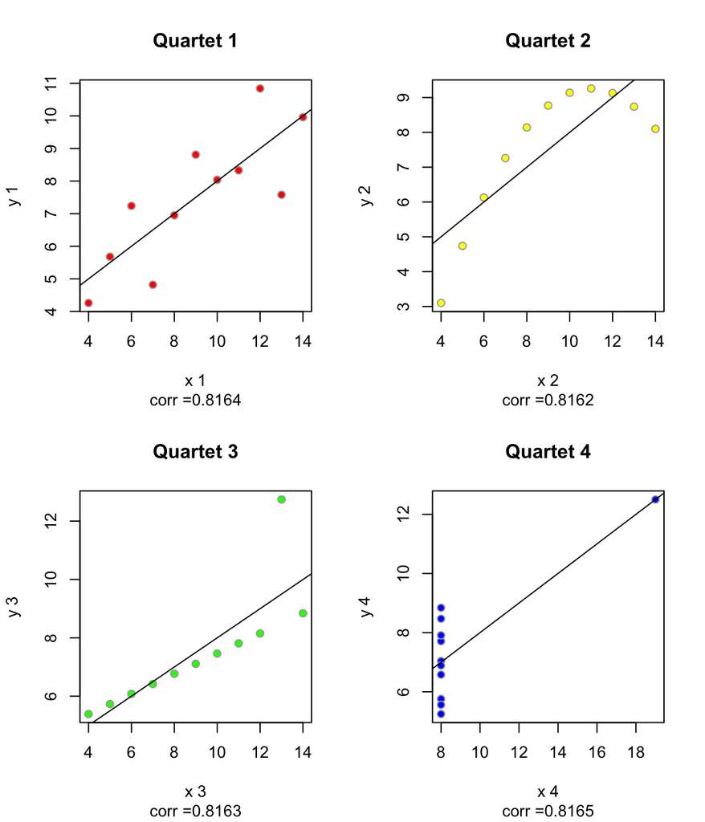

```r
# show four plots
col.fill=c("red", "yellow", "green","blue")

par(mfrow=c(2,2))

# this is a for loop
for(i in 1:4){
nm.txt <- paste("Quartet ",i, sep="")
cor.txt <- paste("corr =", cor.list[[i]], sep="")
plot(anscombe[,i], anscombe[,i+4] , main=nm.txt, sub=cor.txt,
    xlab=paste("x",i), ylab=paste("y",i), pch=21, col="darkgrey", bg=col.fill[i])
abline(cor.list[[i+4]])
}
```